# Analysis of Multiple Linear Regression Models

Longhai Li

September 8, 2025

```r
library(knitr)
library(rmarkdown)
# This chunk sets up the global options for the document.
knitr::opts_chunk$set(
    fig.height = 6,
    fig.width = 9,
    message = FALSE,
    warning = FALSE,
    comment = "#",
    include = TRUE,
    cache = FALSE
)
```

# 1 Fit of the multiple linear regression

This section analyzes the wire bond strength dataset.

## 1.1 Data Loading and Visualization

**Note:** You must change the file paths in the `read.csv()` functions below to match the location of the files on your computer for example “C:<YourUsername>” on windows.

```r
# Read data. Change the path as necessary.
# Example: bond.data <- read.csv("data/wire-bond.csv")
bond.data <- read.csv("wire-bond.csv")

# This will now be automatically rendered as a paged table
bond.data
```

| strength | length | height |
| --- | --- | --- |
| 9.95 | 2 | 50 |
| 24.45 | 8 | 110 |
| 31.75 | 11 | 120 |
| 35.00 | 10 | 550 |
| 25.02 | 8 | 295 |
| 16.86 | 4 | 200 |
| 14.38 | 2 | 375 |
| 9.60 | 2 | 52 |
| 24.35 | 9 | 100 |
| 27.50 | 8 | 300 |

[output cut: 15 more lines]

**2D Visualization**

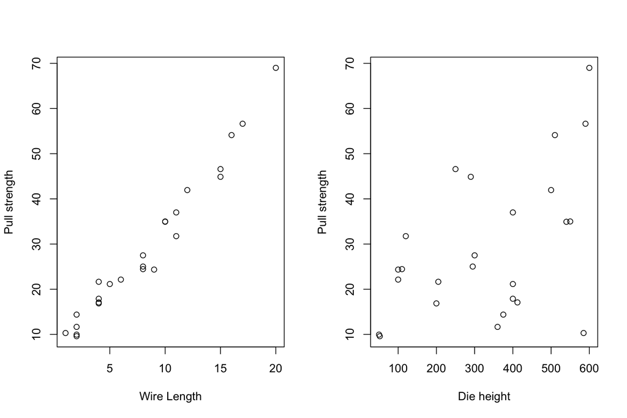

```r
# Create initial scatter plots
par(mfrow = c(1, 2))
plot(bond.data$length, bond.data$strength,
     xlab = "Wire Length", ylab = "Pull strength")
plot(bond.data$height, bond.data$strength,
     xlab = "Die height", ylab = "Pull strength")
```

**3D Visualize**

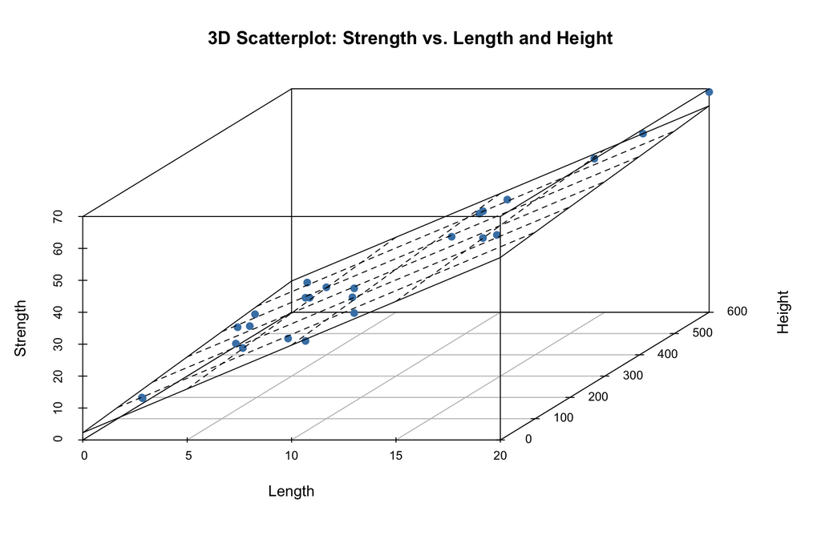

```r
# 1. Install and load the required package

library(scatterplot3d)

par (mfrow = c(1,1))
# 2. Create the 3D scatterplot and store its object
s3d <- with(bond.data, scatterplot3d(
  x = length,
  y = height,
  z = strength,
  pch = 19,
  color = "steelblue",
  main = "3D Scatterplot: Strength vs. Length and Height",
  xlab = "Length",
  ylab = "Height",
  zlab = "Strength",
  angle = 60
))

# 3. Fit a linear model
fit <- lm(strength ~ length + height, data = bond.data)

# 4. Add the regression plane to the plot
s3d$plane3d(fit, lty.box = "solid")
```

**Dynamic 3D Visualization of 3D Data**

```r
# 1. Load necessary libraries
library(plotly)
library(dplyr)

# NOTE: This script assumes you have a data frame named 'bond.data'
# with columns 'length', 'height', and 'strength' already loaded.

# 2. Create the initial scatter plot object
fig <- plot_ly(
  data = bond.data,
  x = ~length,
  y = ~height,
  z = ~strength
) %>%
  add_markers(
    marker = list(
      color = ~strength,
      colorscale = 'Viridis',
      showscale = TRUE,
      colorbar = list(title = 'Strength')
    ),
    name = 'Data Points'
  ) %>%
  layout(
    title = "Interactive 3D Scatter Plot of Bond Strength",
    scene = list(
      xaxis = list(title = 'Length'),
      yaxis = list(title = 'Height'),
      zaxis = list(title = 'Strength')
    )
  )

# 3. Display the scatter plot
# In an interactive session (like RStudio), this line will render the plot.
fig
```

[interactive chart not shown]

**Add Fitted Surface**

```r
# 4. Fit a linear model to the data
fit <- lm(strength ~ length + height, data = bond.data)

# 5. Prepare data for the regression plane surface
resolution <- 20
axis_x <- seq(min(bond.data$length), max(bond.data$length), length.out = resolution)
axis_y <- seq(min(bond.data$height), max(bond.data$height), length.out = resolution)

z_matrix <- outer(
  axis_x,
  axis_y,
  function(len, ht) {
    predict(fit, newdata = data.frame(length = len, height = ht))
  }
)

# 6. Add the surface to the EXISTING plot object and display the result
fig <- fig %>%
  add_surface(
    x = ~axis_x,
    y = ~axis_y,
    z = ~z_matrix,
    colorscale = 'Blues',
    opacity = 0.7,
    showscale = FALSE,
    name = 'Regression Plane'
  )

# 7. Display the final, updated plot
fig
```

[interactive chart not shown]

## 1.2 Model Fitting and Summary

We fit a multiple linear regression model with `strength` as the response variable and `length` and `height` as predictors.

```r
# Fit the linear model
fit <- lm(strength ~ length + height, data = bond.data)

# Display the classic summary output (this is not a data frame, so it's unaffected)
summary(fit)
```

```
#
# Call:
# lm(formula = strength ~ length + height, data = bond.data)
#
# Residuals:
#    Min     1Q Median     3Q    Max
# -3.865 -1.542 -0.362  1.196  5.841
#
# Coefficients:
#             Estimate Std. Error t value Pr(>|t|)
# (Intercept) 2.263791   1.060066   2.136 0.044099 *
# length      2.744270   0.093524  29.343  < 2e-16 ***
# height      0.012528   0.002798   4.477 0.000188 ***
# ---
# Signif. codes:  0 '***' 0.001 '**' 0.01 '*' 0.05 '.' 0.1 ' ' 1
#
# Residual standard error: 2.288 on 22 degrees of freedom
# Multiple R-squared:  0.9811,  Adjusted R-squared:  0.9794
# F-statistic: 572.2 on 2 and 22 DF,  p-value: < 2.2e-16
```

The summary provides the ANOVA F-test for overall significance, $R^2$, adjusted $R^2$, and t-tests for individual coefficients.

## 1.3 Confidence Intervals and Model Components

We can extract confidence intervals for the regression coefficients, as well as fitted values and residuals.

```r
# Confidence intervals (matrix output, will be auto-paged)
confint(fit)
```

```
#                   2.5 %     97.5 %
# (Intercept) 0.065348613 4.46223426
# length      2.550313061 2.93822623
# height      0.006724246 0.01833138
```

```r
# Fitted values and ordinary residuals (matrix output, will be auto-paged)
pred <- fitted.values(fit)
e <- resid(fit)
data.frame(y = bond.data$strength, y.hat = pred, e = e)
```

|  | y | y.hat | e |
| --- | --- | --- | --- |
| 1 | 9.95 | 8.378721 | 1.57127871 |
| 2 | 24.45 | 25.596008 | -1.14600783 |
| 3 | 31.75 | 33.954095 | -2.20409488 |
| 4 | 35.00 | 36.596784 | -1.59678413 |
| 5 | 25.02 | 27.913653 | -2.89365294 |
| 6 | 16.86 | 15.746432 | 1.11356772 |
| 7 | 14.38 | 12.450260 | 1.92974001 |
| 8 | 9.60 | 8.403777 | 1.19622309 |
| 9 | 24.35 | 28.214999 | -3.86499936 |
| 10 | 27.50 | 27.976292 | -0.47629200 |

[output cut: 15 more lines]

```r
# Extract covariance matrix (matrix output, will be auto-paged)
cov.mat <- vcov(fit)
cov.mat
```

```
#              (Intercept)        length        height
# (Intercept)  1.123740429 -3.921612e-02 -1.781991e-03
# length      -0.039216122  8.746709e-03 -9.903775e-05
# height      -0.001781991 -9.903775e-05  7.831149e-06
```

```r
# Standard errors (vector output, needs to be a data.frame to be paged)
data.frame(std.error = sqrt(diag(cov.mat)))
```

|  | std.error |
| --- | --- |
| (Intercept) | 1.060066238 |
| length | 0.093523844 |
| height | 0.002798419 |

# 2 Partial F-test and t-test

This section uses data on the weight, height, and age of children to demonstrate partial F-tests.

```r
# Data: Weight, height and age of children
wgt <- c(64, 71, 53, 67, 55, 58, 77, 57, 56, 51, 76, 68)
hgt <- c(57, 59, 49, 62, 51, 50, 55, 48, 42, 42, 61, 57)
age <- c(8, 10, 6, 11, 8, 7, 10, 9, 10, 6, 12, 9)
child.data <- data.frame(wgt, hgt, age)
```

## 2.1 Problem 1: Simple Linear Regression

```r
fit11 <- lm(wgt ~ hgt, data = child.data)
summary(fit11)
```

```
#
# Call:
# lm(formula = wgt ~ hgt, data = child.data)
#
# Residuals:
#     Min      1Q  Median      3Q     Max
# -5.8736 -3.8973 -0.4402  2.2624 11.8375
#
# Coefficients:
#             Estimate Std. Error t value Pr(>|t|)
# (Intercept)   6.1898    12.8487   0.482  0.64035
# hgt           1.0722     0.2417   4.436  0.00126 **
# ---
# Signif. codes:  0 '***' 0.001 '**' 0.01 '*' 0.05 '.' 0.1 ' ' 1
#
# Residual standard error: 5.471 on 10 degrees of freedom
# Multiple R-squared:  0.663,   Adjusted R-squared:  0.6293
# F-statistic: 19.67 on 1 and 10 DF,  p-value: 0.001263
```

## 2.2 Problem 2: Adding a Predictor

Here we test if adding `age` significantly improves the model that already contains `hgt`.

```r
fit21 <- lm(wgt ~ hgt + age, data = child.data)
summary(fit21)
```

```
#
# Call:
# lm(formula = wgt ~ hgt + age, data = child.data)
#
# Residuals:
#     Min      1Q  Median      3Q     Max
# -6.8708 -1.7004  0.3454  1.4642 10.2336
#
# Coefficients:
#             Estimate Std. Error t value Pr(>|t|)
# (Intercept)   6.5530    10.9448   0.599   0.5641
# hgt           0.7220     0.2608   2.768   0.0218 *
# age           2.0501     0.9372   2.187   0.0565 .
# ---
# Signif. codes:  0 '***' 0.001 '**' 0.01 '*' 0.05 '.' 0.1 ' ' 1
#
# Residual standard error: 4.66 on 9 degrees of freedom
# Multiple R-squared:   0.78,   Adjusted R-squared:  0.7311
# F-statistic: 15.95 on 2 and 9 DF,  p-value: 0.001099
```

```r
# Compare the nested models (anova output is a data frame, will be auto-paged)
fit22 <- lm(wgt ~ hgt, data = child.data)
anova(fit22, fit21)
```

|  | Res.Df | RSS | Df | Sum of Sq | F | Pr(>F) |
| --- | --- | --- | --- | --- | --- | --- |
| 1 | 10 | 299.3275 | NA | NA | NA | NA |
| 2 | 9 | 195.4274 | 1 | 103.9001 | 4.784901 | 0.05648531 |

## 2.3 Problem 3: Adding a Polynomial Term

We test if adding a quadratic term for `age` improves the model with `hgt` and `age`.

```r
fit31 <- lm(wgt ~ hgt + age + I(age^2), data = child.data)
summary(fit31)
```

```
#
# Call:
# lm(formula = wgt ~ hgt + age + I(age^2), data = child.data)
#
# Residuals:
#    Min     1Q Median     3Q    Max
# -6.806 -1.771  0.374  1.374 10.161
#
# Coefficients:
#             Estimate Std. Error t value Pr(>|t|)
# (Intercept)  3.43843   33.61082   0.102    0.921
# hgt          0.72369    0.27696   2.613    0.031 *
# age          2.77687    7.42728   0.374    0.718
# I(age^2)    -0.04171    0.42241  -0.099    0.924
# ---
# Signif. codes:  0 '***' 0.001 '**' 0.01 '*' 0.05 '.' 0.1 ' ' 1
#
# Residual standard error: 4.94 on 8 degrees of freedom
# Multiple R-squared:  0.7803,  Adjusted R-squared:  0.6978
# F-statistic: 9.469 on 3 and 8 DF,  p-value: 0.005208
```

```r
fit32 <- lm(wgt ~ hgt + age, data = child.data)
anova(fit32, fit31)
```

|  | Res.Df | RSS | Df | Sum of Sq | F | Pr(>F) |
| --- | --- | --- | --- | --- | --- | --- |
| 1 | 9 | 195.4274 | NA | NA | NA | NA |
| 2 | 8 | 195.1895 | 1 | 0.2378569 | 0.009748754 | 0.9237772 |

## 2.4 Problem 4: Testing Multiple Coefficients

We test if the `age` and `age^2` terms are jointly significant.

```r
fit41 <- lm(wgt ~ hgt + age + I(age^2), data = child.data)
fit42 <- lm(wgt ~ hgt, data = child.data)
anova(fit42, fit41)
```

|  | Res.Df | RSS | Df | Sum of Sq | F | Pr(>F) |
| --- | --- | --- | --- | --- | --- | --- |
| 1 | 10 | 299.3275 | NA | NA | NA | NA |
| 2 | 8 | 195.1895 | 2 | 104.1379 | 2.134089 | 0.1808172 |

# 3 Mean Response and Prediction Intervals

This section demonstrates how to calculate confidence and prediction intervals for the wire bond strength data.

## 3.1 Confidence Interval for Mean Response

Construct a 95% CI on the mean pull strength for a wire bond with wire length = 8 and die height = 275.

```r
# We use the model 'fit' from the first section (predict output is a matrix)
predict(fit, newdata = data.frame(length = 8, height = 275),
        interval = "confidence", level = 0.95)
```

```
#       fit      lwr      upr
# 1 27.6631 26.66324 28.66296
```

## 3.2 Prediction Interval for a New Observation

Construct a 95% PI on the pull strength for a new wire bond with wire length = 8 and die height = 275.

```r
predict(fit, newdata = data.frame(length = 8, height = 275),
        interval = "prediction", level = 0.95)
```

```
#       fit      lwr      upr
# 1 27.6631 22.81378 32.51241
```

# 4 Model Diagnostics

This section covers various methods for diagnosing the model fit using residuals and other measures.

## 4.1 Residual Calculations

We can calculate hat values, and various types of residuals. They are combined here into a single data frame which will be auto-paged.

```r
residuals_df <- data.frame(
  hat_values = hatvalues(fit),
  ordinary_resid = resid(fit),
  standardized_resid = resid(fit) / sigma(fit),
  studentized_internal = rstandard(fit),
  studentized_external = rstudent(fit)
)
residuals_df
```

|  | hat_values | ordinary_resid | standardized_resid | studentized_internal | studentized_external |
| --- | --- | --- | --- | --- | --- |
| 1 | 0.15728923 | 1.57127871 | 0.68673363 | 0.74808172 | 0.74035927 |
| 2 | 0.11164598 | -1.14600783 | -0.50086730 | -0.53140990 | -0.52255660 |
| 3 | 0.14191905 | -2.20409488 | -0.96330846 | -1.03992315 | -1.04194550 |
| 4 | 0.10188923 | -1.59678413 | -0.69788088 | -0.73640435 | -0.72850799 |
| 5 | 0.04178381 | -2.89365294 | -1.26468257 | -1.29196212 | -1.31305171 |
| 6 | 0.07486842 | 1.11356772 | 0.48668921 | 0.50599936 | 0.49726770 |
| 7 | 0.11806106 | 1.92974001 | 0.84340057 | 0.89807919 | 0.89397096 |
| 8 | 0.15608149 | 1.19622309 | 0.52281407 | 0.56911105 | 0.56016499 |
| 9 | 0.12797685 | -3.86499936 | -1.68921340 | -1.80892479 | -1.91552083 |
| 10 | 0.04131672 | -0.47629200 | -0.20816532 | -0.21260369 | -0.20792931 |

[output cut: 15 more lines]

## 4.2 Residual Plots

A common practice is to analyze plots of the studentized residuals to check for non-linearity, non-constant variance, and non-normality.

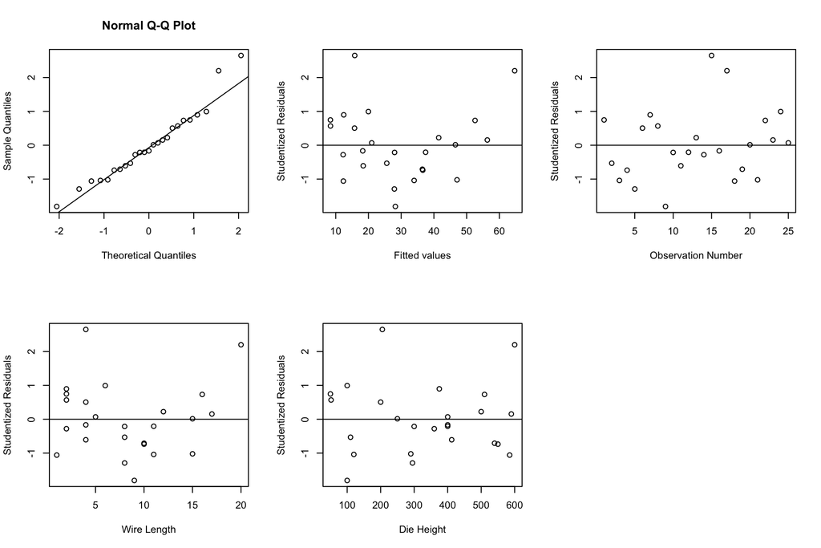

```r
# Residual analysis using internally studentized residuals
n <- nrow(bond.data)
r <- rstandard(fit)
y.hat <- fitted.values(fit)

par(mfrow = c(2, 3))
qqnorm(r, main = "Normal Q-Q Plot")
qqline(r)
plot(y.hat, r, xlab = "Fitted values", ylab = "Studentized Residuals")
abline(h = 0)
plot(1:n, r, xlab = "Observation Number", ylab = "Studentized Residuals")
abline(h = 0)
plot(bond.data$length, r, xlab = "Wire Length", ylab = "Studentized Residuals")
abline(h = 0)
plot(bond.data$height, r, xlab = "Die Height", ylab = "Studentized Residuals")
abline(h = 0)
```

# 5 Influential Observations

We can identify influential data points using metrics like DFFITS, DFBETAS, and Cook’s D.

```r
# Find DFFITS, DFBETAS and Cook's D for the wire bond strength data.
influence_df <- data.frame(dffits = dffits(fit), cook.D = cooks.distance(fit), dfbetas(fit))
influence_df
```

|  | dffits | cook.D | X.Intercept. | length | height |
| --- | --- | --- | --- | --- | --- |
| 1 | 0.319854702 | 3.481748e-02 | 0.3179493921 | -0.100534181 | -0.200085326 |
| 2 | -0.185251548 | 1.183028e-02 | -0.1403477437 | -0.051464370 | 0.148315370 |
| 3 | -0.423741713 | 5.962023e-02 | -0.2219151046 | -0.237135616 | 0.339340552 |
| 4 | -0.245376811 | 2.050736e-02 | 0.0787635526 | 0.022343842 | -0.184260891 |
| 5 | -0.274191565 | 2.426179e-02 | -0.1572410603 | -0.009662357 | 0.055328303 |
| 6 | 0.141461363 | 6.906752e-03 | 0.1301249135 | -0.058073567 | -0.049408295 |
| 7 | 0.327082639 | 3.598953e-02 | 0.1479853099 | -0.261848970 | 0.142220906 |
| 8 | 0.240902557 | 1.996750e-02 | 0.2394962591 | -0.076575387 | -0.149787102 |
| 9 | -0.733818383 | 1.600749e-01 | -0.5011686139 | -0.283749099 | 0.605559181 |
| 10 | -0.043165927 | 6.493384e-04 | -0.0241138520 | -0.001038287 | 0.007460760 |

[output cut: 15 more lines]

## 5.1 Plotting with the `olsrr` Package

The `olsrr` package provides convenient functions for plotting these influence diagnostics. Note: You only need to run `install.packages("olsrr")` once.

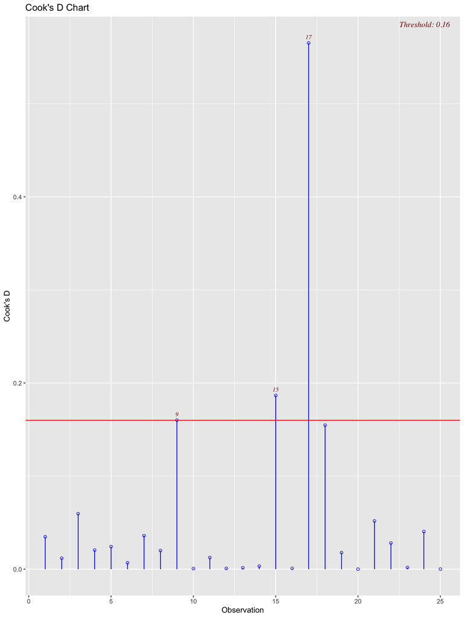

```r
# install.packages("olsrr") # Run this once if you don't have the package
library(olsrr)

# Plot for Cook's D
ols_plot_cooksd_chart(fit)
```

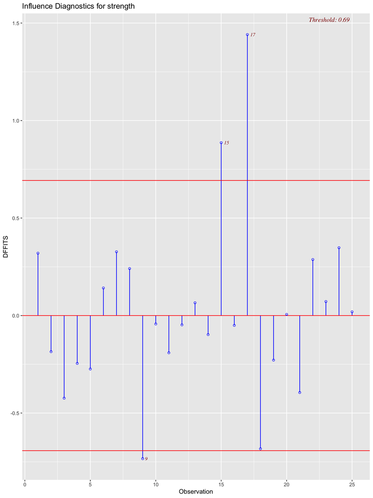

```r
# Plot for DFFITS
ols_plot_dffits(fit)
```

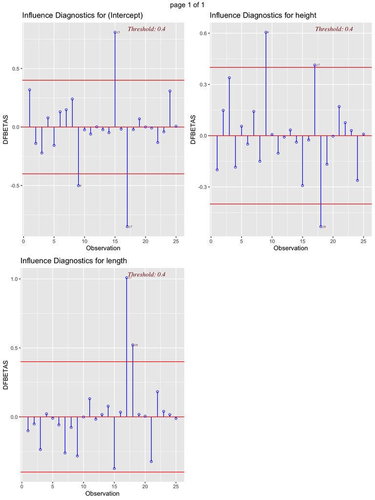

```r
# Plot for DFBETAS
ols_plot_dfbetas(fit)
```

# 6 Polynomial Regression

This example uses data on the cost and production lot size of airplane sidewall panels.

```r
y <- c(1.81, 1.70, 1.65, 1.55, 1.48, 1.40, 1.30, 1.26, 1.24, 1.21, 1.20, 1.18)
x <- c(20, 25, 30, 35, 40, 50, 60, 65, 70, 75, 80, 90)
fit_poly <- lm(y ~ x + I(x^2))
summary(fit_poly)
```

```
#
# Call:
# lm(formula = y ~ x + I(x^2))
#
# Residuals:
#        Min         1Q     Median         3Q        Max
# -0.0174763 -0.0065087  0.0001297  0.0071482  0.0151887
#
# Coefficients:
#               Estimate Std. Error t value Pr(>|t|)
# (Intercept)  2.198e+00  2.255e-02   97.48 6.38e-15 ***
# x           -2.252e-02  9.424e-04  -23.90 1.88e-09 ***
# I(x^2)       1.251e-04  8.658e-06   14.45 1.56e-07 ***
# ---
# Signif. codes:  0 '***' 0.001 '**' 0.01 '*' 0.05 '.' 0.1 ' ' 1
#
# Residual standard error: 0.01219 on 9 degrees of freedom
# Multiple R-squared:  0.9975,  Adjusted R-squared:  0.9969
# F-statistic:  1767 on 2 and 9 DF,  p-value: 2.096e-12
```

The plot shows the fitted quadratic curve.

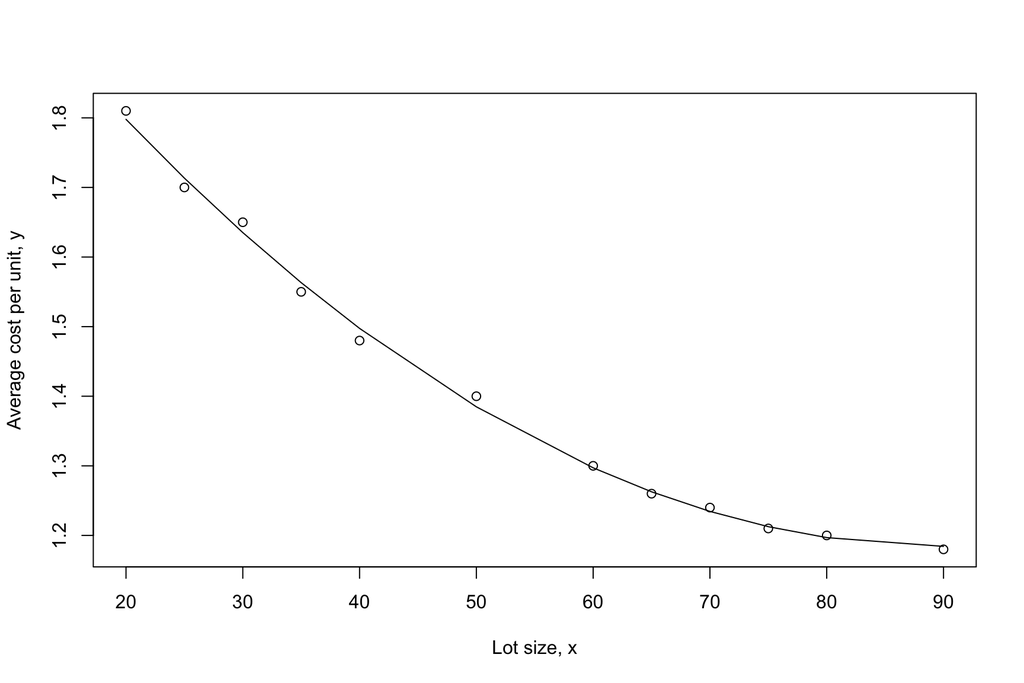

```r
plot(x, y, xlab = "Lot size, x", ylab = "Average cost per unit, y")
lines(x, predict(fit_poly, newdata = data.frame(x = x)), type = "l")
```

We can use a partial F-test to see if the quadratic term significantly improves the model.

```r
fit1 <- lm(y ~ x)
anova(fit1, fit_poly)
```

|  | Res.Df | RSS | Df | Sum of Sq | F | Pr(>F) |
| --- | --- | --- | --- | --- | --- | --- |
| 1 | 10 | 0.032339665 | NA | NA | NA | NA |
| 2 | 9 | 0.001337125 | 1 | 0.03100254 | 208.6737 | 1.563952e-07 |

# 7 Indicator Variables

This section uses the SBP (Systolic Blood Pressure) dataset to model the effect of a categorical variable (`sex`).

```r
# Note: Update this path to your local file location
sbpdata <- read.csv("sbpdata.csv")

# Fit the full model with an interaction term
fit.full <- lm(sbp ~ age + sex + age:sex, data = sbpdata)
summary(fit.full)
```

```
#
# Call:
# lm(formula = sbp ~ age + sex + age:sex, data = sbpdata)
#
# Residuals:
#     Min      1Q  Median      3Q     Max
# -20.647  -3.410   1.254   4.314  21.153
#
# Coefficients:
#             Estimate Std. Error t value Pr(>|t|)
# (Intercept) 97.07708    5.17046  18.775  < 2e-16 ***
# age          0.94932    0.10864   8.738 1.43e-12 ***
# sex         12.96144    7.01172   1.849   0.0691 .
# age:sex      0.01203    0.14519   0.083   0.9342
# ---
# Signif. codes:  0 '***' 0.001 '**' 0.01 '*' 0.05 '.' 0.1 ' ' 1
#
# Residual standard error: 8.946 on 65 degrees of freedom
# Multiple R-squared:  0.7759,  Adjusted R-squared:  0.7656
# F-statistic: 75.02 on 3 and 65 DF,  p-value: < 2.2e-16
```

## 7.1 Hypothesis Tests for Indicator Models

We can perform various hypothesis tests to see if the lines are coincident, parallel, or have equal intercepts.

```r
# Test of Coincidence. H0: beta2=beta3=0
fit.coin <- lm(sbp ~ age, data = sbpdata)
anova(fit.coin, fit.full)
```

|  | Res.Df | RSS | Df | Sum of Sq | F | Pr(>F) |
| --- | --- | --- | --- | --- | --- | --- |
| 1 | 67 | 8260.514 | NA | NA | NA | NA |
| 2 | 65 | 5201.439 | 2 | 3059.074 | 19.11392 | 2.959962e-07 |

```r
# Test of Parallelism. H0: beta3=0
fit.para <- lm(sbp ~ age + sex, data = sbpdata)
anova(fit.para, fit.full)
```

|  | Res.Df | RSS | Df | Sum of Sq | F | Pr(>F) |
| --- | --- | --- | --- | --- | --- | --- |
| 1 | 66 | 5201.989 | NA | NA | NA | NA |
| 2 | 65 | 5201.439 | 1 | 0.5493562 | 0.006865052 | 0.934221 |

```r
# Test for Equal Intercepts. H0: beta2=0 (assuming parallel lines)
fit1.inter <- lm(sbp ~ age + sex, data = sbpdata)
fit2.inter <- lm(sbp ~ age, data = sbpdata)
anova(fit2.inter, fit1.inter)
```

|  | Res.Df | RSS | Df | Sum of Sq | F | Pr(>F) |
| --- | --- | --- | --- | --- | --- | --- |
| 1 | 67 | 8260.514 | NA | NA | NA | NA |
| 2 | 66 | 5201.989 | 1 | 3058.525 | 38.8049 | 3.701318e-08 |

## 7.2 Plotting the Fitted Model

The plot below shows the separate regression lines for males and females.

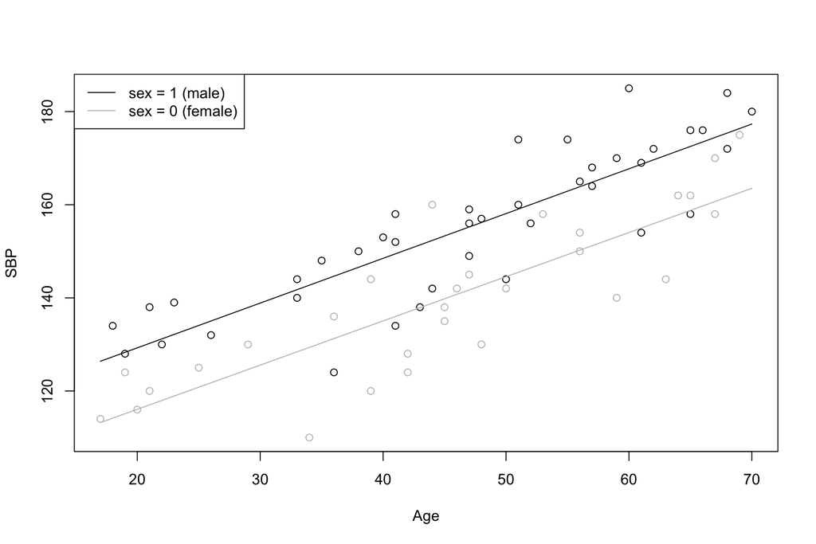

```r
# Define color for males (sex=1) and females (sex=0).
colors <- ifelse(sbpdata$sex == 1, "black", "gray")

# Scatter plot
plot(sbpdata$age, sbpdata$sbp, xlab = "Age", ylab = "SBP", col = colors)

# Add the fitted lines for males and females
# The design matrix is data.frame(1, age, 1, age) for sex = 1,
# and data.frame(1, age, 0, 0) for sex = 0.
lines(sbpdata$age, cbind(1, sbpdata$age, 1, sbpdata$age) %*% coef(fit.full), col = "black")
lines(sbpdata$age, cbind(1, sbpdata$age, 0, 0) %*% coef(fit.full), col = "gray")

# Add legend
legend("topleft", legend = c("sex = 1 (male)", "sex = 0 (female)"),
       lty = c(1, 1), col = c("black", "gray"))
```

# 8 Model Building

This section uses the `olsrr` package and wine quality data to demonstrate automated model selection techniques.

```r
library(olsrr)
# Note: Update this path to your local file location
wine <- read.csv("wine.csv")

# A dot in the lm function means: use all other variables as predictors.
model <- lm(quality ~ ., data = wine)
```

## 8.1 All Possible Regression

This method evaluates every possible combination of predictors. The output is a data frame and will be auto-paged.

```r
ols_step_best_subset(model)
```

```
#              Best Subsets Regression
# -------------------------------------------------
# Model Index    Predictors
# -------------------------------------------------
#      1         flavor
#      2         flavor oakiness
#      3         aroma flavor oakiness
#      4         clarity aroma flavor oakiness
#      5         clarity aroma body flavor oakiness
# -------------------------------------------------
#
#                                                   Subsets Regression Summary
# -------------------------------------------------------------------------------------------------------------------------------
#                        Adj.        Pred
# Model    R-Square    R-Square    R-Square     C(p)       AIC        SBIC        SBC        MSEP       FPE       HSP       APC
# -------------------------------------------------------------------------------------------------------------------------------
#   1        0.6242      0.6137      0.5868    9.0436    130.0214    21.6859    134.9341    61.4102    1.7010    0.0462    0.4176
#   2        0.6611      0.6417      0.6058    6.8132    128.0901    20.1242    134.6404    57.0033    1.6171    0.0441    0.3970
#   3        0.7038      0.6776      0.6379    3.9278    124.9781    18.0702    133.1661    51.3383    1.4906    0.0409    0.3659
#   4        0.7147      0.6801      0.6102    4.6747    125.5480    19.2854    135.3736    50.9872    1.5143    0.0418    0.3717
#   5        0.7206      0.6769       0.587    6.0000    126.7552    21.0956    138.2183    51.5452    1.5649    0.0436    0.3842
# -------------------------------------------------------------------------------------------------------------------------------
# AIC: Akaike Information Criteria
#  SBIC: Sawa's Bayesian Information Criteria
#  SBC: Schwarz Bayesian Criteria
#  MSEP: Estimated error of prediction, assuming multivariate normality
#  FPE: Final Prediction Error
#  HSP: Hocking's Sp
#  APC: Amemiya Prediction Criteria
```

## 8.2 Automated Stepwise Procedures

We can also use backward, forward, or stepwise selection to find a good model. These functions also return data frames.

```r
# Backward Elimination (alpha_out = 0.1)
ols_step_backward_p(model, p_val = 0.1)
```

```
#
#
#                              Stepwise Summary
# ------------------------------------------------------------------------
# Step    Variable        AIC        SBC       SBIC       R2       Adj. R2
# ------------------------------------------------------------------------
#  0      Full Model    126.755    138.218    21.096    0.72060    0.67694
#  1      body          125.548    135.374    19.285    0.71471    0.68013
#  2      clarity       124.978    133.166    18.070    0.70377    0.67763
# ------------------------------------------------------------------------
#
# Final Model Output
# ------------------
#
#                          Model Summary
# ---------------------------------------------------------------
# R                       0.839       RMSE                 1.098
# R-Squared               0.704       MSE                  1.207
# Adj. R-Squared          0.678       Coef. Var            9.338
# Pred R-Squared          0.638       AIC                124.978
# MAE                     0.868       SBC                133.166
# ---------------------------------------------------------------
#  RMSE: Root Mean Square Error
#  MSE: Mean Square Error
#  MAE: Mean Absolute Error
#  AIC: Akaike Information Criteria
#  SBC: Schwarz Bayesian Criteria
#
#                                ANOVA
# -------------------------------------------------------------------
#                Sum of
#               Squares        DF    Mean Square      F         Sig.
# -------------------------------------------------------------------
# Regression    108.935         3         36.312    26.925    0.0000
# Residual       45.853        34          1.349
# Total         154.788        37
# -------------------------------------------------------------------
#
#                                   Parameter Estimates
# ----------------------------------------------------------------------------------------
#       model      Beta    Std. Error    Std. Beta      t        Sig      lower     upper
# ----------------------------------------------------------------------------------------
# (Intercept)     6.467         1.333                  4.852    0.000     3.759     9.176
#       aroma     0.580         0.262        0.307     2.213    0.034     0.047     1.113
#      flavor     1.200         0.275        0.603     4.364    0.000     0.641     1.758
#    oakiness    -0.602         0.264       -0.217    -2.278    0.029    -1.140    -0.065
# ----------------------------------------------------------------------------------------
```

```r
# Forward Selection (alpha_in = 0.1)
ols_step_forward_p(model, p_val = 0.1)
```

```
#
#
#                              Stepwise Summary
# ------------------------------------------------------------------------
# Step    Variable        AIC        SBC       SBIC       R2       Adj. R2
# ------------------------------------------------------------------------
#  0      Base Model    165.209    168.484    55.141    0.00000    0.00000
#  1      flavor        130.021    134.934    21.686    0.62417    0.61373
#  2      oakiness      128.090    134.640    20.124    0.66111    0.64175
#  3      aroma         124.978    133.166    18.070    0.70377    0.67763
# ------------------------------------------------------------------------
#
# Final Model Output
# ------------------
#
#                          Model Summary
# ---------------------------------------------------------------
# R                       0.839       RMSE                 1.098
# R-Squared               0.704       MSE                  1.207
# Adj. R-Squared          0.678       Coef. Var            9.338
# Pred R-Squared          0.638       AIC                124.978
# MAE                     0.868       SBC                133.166
# ---------------------------------------------------------------
#  RMSE: Root Mean Square Error
#  MSE: Mean Square Error
#  MAE: Mean Absolute Error
#  AIC: Akaike Information Criteria
#  SBC: Schwarz Bayesian Criteria
#
#                                ANOVA
# -------------------------------------------------------------------
#                Sum of
#               Squares        DF    Mean Square      F         Sig.
# -------------------------------------------------------------------
# Regression    108.935         3         36.312    26.925    0.0000
# Residual       45.853        34          1.349
# Total         154.788        37
# -------------------------------------------------------------------
#
#                                   Parameter Estimates
# ----------------------------------------------------------------------------------------
#       model      Beta    Std. Error    Std. Beta      t        Sig      lower     upper
# ----------------------------------------------------------------------------------------
# (Intercept)     6.467         1.333                  4.852    0.000     3.759     9.176
#      flavor     1.200         0.275        0.603     4.364    0.000     0.641     1.758
#    oakiness    -0.602         0.264       -0.217    -2.278    0.029    -1.140    -0.065
#       aroma     0.580         0.262        0.307     2.213    0.034     0.047     1.113
# ----------------------------------------------------------------------------------------
```

```r
# Stepwise Regression (alpha_in = 0.1, alpha_out = 0.1)
ols_step_both_p(model, p_enter = 0.1, p_remove = 0.1)
```

```
#
#
#                               Stepwise Summary
# --------------------------------------------------------------------------
# Step    Variable          AIC        SBC       SBIC       R2       Adj. R2
# --------------------------------------------------------------------------
#  0      Base Model      165.209    168.484    55.141    0.00000    0.00000
#  1      flavor (+)      130.021    134.934    21.686    0.62417    0.61373
#  2      oakiness (+)    128.090    134.640    20.124    0.66111    0.64175
#  3      aroma (+)       124.978    133.166    18.070    0.70377    0.67763
# --------------------------------------------------------------------------
#
# Final Model Output
# ------------------
#
#                          Model Summary
# ---------------------------------------------------------------
# R                       0.839       RMSE                 1.098
# R-Squared               0.704       MSE                  1.207
# Adj. R-Squared          0.678       Coef. Var            9.338
# Pred R-Squared          0.638       AIC                124.978
# MAE                     0.868       SBC                133.166
# ---------------------------------------------------------------
#  RMSE: Root Mean Square Error
#  MSE: Mean Square Error
#  MAE: Mean Absolute Error
#  AIC: Akaike Information Criteria
#  SBC: Schwarz Bayesian Criteria
#
#                                ANOVA
# -------------------------------------------------------------------
#                Sum of
#               Squares        DF    Mean Square      F         Sig.
# -------------------------------------------------------------------
# Regression    108.935         3         36.312    26.925    0.0000
# Residual       45.853        34          1.349
# Total         154.788        37
# -------------------------------------------------------------------
#
#                                   Parameter Estimates
# ----------------------------------------------------------------------------------------
#       model      Beta    Std. Error    Std. Beta      t        Sig      lower     upper
# ----------------------------------------------------------------------------------------
# (Intercept)     6.467         1.333                  4.852    0.000     3.759     9.176
#      flavor     1.200         0.275        0.603     4.364    0.000     0.641     1.758
#    oakiness    -0.602         0.264       -0.217    -2.278    0.029    -1.140    -0.065
#       aroma     0.580         0.262        0.307     2.213    0.034     0.047     1.113
# ----------------------------------------------------------------------------------------
```

# 9 Multicollinearity

This section explores the issue of multicollinearity, where predictors are highly correlated.

## 9.1 A Simple Example

```r
y <- c(19, 20, 37, 39, 36, 38)
x1 <- c(4, 4, 7, 7, 7.1, 7.1)
x2 <- c(16, 16, 49, 49, 50.4, 50.4)
cor(data.frame(x1, x2))
```

```
#           x1        x2
# x1 1.0000000 0.9999713
# x2 0.9999713 1.0000000
```

```r
# Full model
fit_multi <- lm(y ~ x1 + x2)
summary(fit_multi)
```

```
#
# Call:
# lm(formula = y ~ x1 + x2)
#
# Residuals:
#    1    2    3    4    5    6
# -0.5  0.5 -1.0  1.0 -1.0  1.0
#
# Coefficients:
#             Estimate Std. Error t value Pr(>|t|)
# (Intercept) -156.056    117.158  -1.332    0.275
# x1            65.444     45.890   1.426    0.249
# x2            -5.389      4.152  -1.298    0.285
#
# Residual standard error: 1.225 on 3 degrees of freedom
# Multiple R-squared:  0.9897,  Adjusted R-squared:  0.9829
# F-statistic: 144.3 on 2 and 3 DF,  p-value: 0.001043
```

```r
# Simple model
fit1_multi <- lm(y ~ x1)
summary(fit1_multi)
```

```
#
# Call:
# lm(formula = y ~ x1)
#
# Residuals:
#       1       2       3       4       5       6
# -0.5260  0.4740 -0.1925  1.8075 -1.7814  0.2186
#
# Coefficients:
#             Estimate Std. Error t value Pr(>|t|)
# (Intercept)  -4.0293     2.3332  -1.727    0.159
# x1            5.8888     0.3762  15.654 9.73e-05 ***
# ---
# Signif. codes:  0 '***' 0.001 '**' 0.01 '*' 0.05 '.' 0.1 ' ' 1
#
# Residual standard error: 1.325 on 4 degrees of freedom
# Multiple R-squared:  0.9839,  Adjusted R-squared:  0.9799
# F-statistic: 245.1 on 1 and 4 DF,  p-value: 9.725e-05
```

## 9.2 VIFs in the Wine Quality Data

We can calculate the Variance Inflation Factor (VIF) for each predictor to diagnose multicollinearity. A VIF > 10 is often considered problematic.

```r
wine.x <- wine[, -ncol(wine)] # Assuming quality is the last column
cor(wine.x)
```

```
#              clarity     aroma       body      flavor  oakiness
# clarity   1.00000000 0.0619021 -0.3083783 -0.08515993 0.1832147
# aroma     0.06190210 1.0000000  0.5489102  0.73656121 0.2016444
# body     -0.30837826 0.5489102  1.0000000  0.64665917 0.1521059
# flavor   -0.08515993 0.7365612  0.6466592  1.00000000 0.1797605
# oakiness  0.18321471 0.2016444  0.1521059  0.17976051 1.0000000
```

```r
# Find VIF's using the olsrr package (returns a data frame).
ols_vif_tol(model)
```

| Variables | Tolerance | VIF |
| --- | --- | --- |
| clarity | 0.7896462 | 1.266390 |
| aroma | 0.4199665 | 2.381143 |
| body | 0.4862649 | 2.056492 |
| flavor | 0.3728175 | 2.682277 |
| oakiness | 0.9118005 | 1.096731 |